# Text Analytics (Part 1)

Stefano Galelli

Term 6, 2020

First, we prepare the working environment.

```r
rm(list=ls()) # Clear the environment
# setwd("...")  # Setup the working directory
```

# 1 Data Preparation

Load the twitter data.

```r
twitter <- read.csv("twitter.csv")
str(twitter) # Internal structure of the dataframe
```

```
## 'data.frame':    2664 obs. of  2 variables:
##  $ sentiment: int  5 5 5 5 5 5 5 5 5 5 ...
##  $ tweet    : chr  "Two places I'd invest all my money if I could: 3D printing and Self-driving cars!!!" "Awesome! Google driverless cars will help the blind travel more often; https://t.co/QWuXR0FrBpv" "Autonomous vehicles could reduce traffic fatalities by 90%...I'm in!" "Really good presentati…
```

With the option `stringsAsFactors=FALSE` we make sure that character vectors are NOT converted into factors.

```r
twitter <- read.csv("twitter.csv",stringsAsFactors=FALSE)
# twitter <- read.csv("twitter.csv",stringsAsFactors=FALSE,fileEncoding = "latin1") Alternative command for forcing the file encoding
str(twitter)  # 2664 observations of 2 variables
```

```
## 'data.frame':    2664 obs. of  2 variables:
##  $ sentiment: int  5 5 5 5 5 5 5 5 5 5 ...
##  $ tweet    : chr  "Two places I'd invest all my money if I could: 3D printing and Self-driving cars!!!" "Awesome! Google driverless cars will help the blind travel more often; https://t.co/QWuXR0FrBpv" "Autonomous vehicles could reduce traffic fatalities by 90%...I'm in!" "Really good presentati…
```

A quick look at the dataframe

```r
# head(twitter) # First part of the dataframe
# tail(twitter) # Last part of the dataframe
summary(twitter) # Summary of the data
```

```
##    sentiment       tweet
##  Min.   :1.00   Length:2664
##  1st Qu.:2.00   Class :character
##  Median :4.00   Mode  :character
##  Mean   :3.55
##  3rd Qu.:4.00
##  Max.   :5.00
```

A few comments about the data: - The sentiment takes value 1, 2, 4, and 5, where 1 = very negative, 2 = slightly negative, 4 = slightly positive, and 5 = very positive. - The tweets were classified by the contributors. - The data come from [CrowdFlower](https://www.figure-eight.com/data-for-everyone/), a crowdsourcing data management company which allows users to access online workforce of million of people to clean, label, and enrich data.

Let’s take a look at the negative and very negative tweets

```r
twitter$Neg <- as.factor(twitter$sentiment<=2)
table(twitter$Neg)
```

```
##
## FALSE  TRUE
##  1889   775
```

So, we have `29.0915916`% of tweets with negative sentiment.

# 2 Pre-processing

To create the DTM, we will use the text mining package `tm`. Note that this is a development package, so there could be some variations based on the system you run (e.g., different R versions or different operating systems).

```r
if(!require(tm)){
  install.packages("tm")
  library(tm)
}
```

A corpus represents a collection of documents (tweets, in our case)

```r
?Corpus
```

The `VectorSource` helps interpret each element of the `twitter$tweet` object as a document, while the `Corpus` command helps represent it as a corpus.

```r
?VectorSource
corpus <- Corpus(VectorSource(twitter$tweet))
# corpus
```

Elements of the corpus.

```r
corpus[[1]]
```

```
## <<PlainTextDocument>>
## Metadata:  7
## Content:  chars: 83
```

```r
as.character(corpus[[1]])
```

```
## [1] "Two places I'd invest all my money if I could: 3D printing and Self-driving cars!!!"
```

```r
corpus[[2664]]
```

```
## <<PlainTextDocument>>
## Metadata:  7
## Content:  chars: 60
```

```r
as.character(corpus[[2664]])
```

```
## [1] "I'd never trust a self-driving car to take my kid to school."
```

With the function `tm_map`, we apply mappings (transformations) to the corpus.

```r
?tm_map
```

There is a variety of transformations that we can apply

```r
getTransformations()
```

```
## [1] "removeNumbers"     "removePunctuation" "removeWords"
## [4] "stemDocument"      "stripWhitespace"
```

## 2.1 Convert text to lower case

The first goal is to convert all text to lower case (since R is case sensitive). Although there is a `tolower` transformation, it is not a part of the standard `tm` transformations (see the output of `getTransformations()` in the previous section). For this reason, we have to convert tolower into a transformation that can handle a corpus object properly. This is done with the help of the function `content_transformer`.

```r
# corpus <- tm_map(corpus,content_transformer(tolower))
# corpus <- tm_map(corpus,tolower) # alternative command
```

If the command does not work, try [this trick](https://stackoverflow.com/questions/27756693/fun-error-after-running-tolower-while-making-twitter-wordcloud):

```r
corpus <- tm_map(corpus, function(x) iconv(enc2utf8(x), sub = "byte"))
corpus <- tm_map(corpus, content_transformer(function(x)    iconv(enc2utf8(x), sub = "bytes")))
corpus <- tm_map(corpus, content_transformer(tolower))
```

Let’s now check a couple of documents

```r
as.character(corpus[[2664]])
```

```
## [1] "i'd never trust a self-driving car to take my kid to school."
```

```r
as.character(corpus[[1]])
```

```
## [1] "two places i'd invest all my money if i could: 3d printing and self-driving cars!!!"
```

## 2.2 Remove stopwords

Then, we move on to the stopwords. Here is the list of english stopwords in the `tm` package

```r
stopwords("english")
```

```
##   [1] "i"          "me"         "my"         "myself"     "we"
##   [6] "our"        "ours"       "ourselves"  "you"        "your"
##  [11] "yours"      "yourself"   "yourselves" "he"         "him"
##  [16] "his"        "himself"    "she"        "her"        "hers"
##  [21] "herself"    "it"         "its"        "itself"     "they"
##  [26] "them"       "their"      "theirs"     "themselves" "what"
##  [31] "which"      "who"        "whom"       "this"       "that"
##  [36] "these"      "those"      "am"         "is"         "are"
##  [41] "was"        "were"       "be"         "been"       "being"
##  [46] "have"       "has"        "had"        "having"     "do"
##  [51] "does"       "did"        "doing"      "would"      "should"
##  [56] "could"      "ought"      "i'm"        "you're"     "he's"
##  [61] "she's"      "it's"       "we're"      "they're"    "i've"
##  [66] "you've"     "we've"      "they've"    "i'd"        "you'd"
##  [71] "he'd"       "she'd"      "we'd"       "they'd"     "i'll"
```

[output cut: 20 more lines]

Let’s then remove the stopwords from the corpus

```r
corpus <- tm_map(corpus,removeWords,stopwords("english"))
# And ... Let's check a couple of documents
as.character(corpus[[1]])
```

```
## [1] "two places  invest   money   : 3d printing  self-driving cars!!!"
```

```r
as.character(corpus[[2664]])
```

```
## [1] " never trust  self-driving car  take  kid  school."
```

We also remove the following words: ‘drive’, ‘driving’, ‘driver’, ‘self-driving’, ‘car’, and ‘cars’. The reason is that many tweets contain these words, which are probably not going to be a predictor of the polarity of the tweets.

```r
corpus <- tm_map(corpus,removeWords,c("drive","driving","driver","self-driving","car","cars"))
# And ... Let's check a couple of documents
as.character(corpus[[1]])
```

```
## [1] "two places  invest   money   : 3d printing   !!!"
```

```r
as.character(corpus[[2664]])
```

```
## [1] " never trust     take  kid  school."
```

## 2.3 Remove punctuation

```r
corpus <- tm_map(corpus,removePunctuation)
# And ... Let's check a couple of documents
as.character(corpus[[1]])
```

```
## [1] "two places  invest   money    3d printing   "
```

```r
as.character(corpus[[2664]])
```

```
## [1] " never trust     take  kid  school"
```

## 2.4 Stemming

Finally, we stem the words using Porter’s stemming algorithm. Note that you may need to load the `SnowballC` package to use this functionality. The package is the R interface to the C libstemmer library that implements Porter’s word stemming algorithm.

```r
if(!require(SnowballC)){
  install.packages("SnowballC")
  library(SnowballC)
}
```

Stemming:

```r
corpus <- tm_map(corpus,stemDocument)
# And ... Let's check a couple of documents
as.character(corpus[[1]])
```

```
## [1] "two place invest money 3d print"
```

```r
as.character(corpus[[2664]])
```

```
## [1] "never trust take kid school"
```

Let’s compare the raw information with the post-processed one:

```r
twitter$tweet[1]
```

```
## [1] "Two places I'd invest all my money if I could: 3D printing and Self-driving cars!!!"
```

```r
as.character(corpus[[1]])
```

```
## [1] "two place invest money 3d print"
```

## 2.5 Create DTM

We can now create a document-term matrix from the original corpus.

```r
?DocumentTermMatrix
dtm <- DocumentTermMatrix(corpus)
dtm
```

```
## <<DocumentTermMatrix (documents: 2664, terms: 5649)>>
## Non-/sparse entries: 22176/15026760
## Sparsity           : 100%
## Maximal term length: 41
## Weighting          : term frequency (tf)
```

We have 2664 documents (rows) and 5649 terms (columns). Out of the 1.504893610^{7} terms, 22176 terms are nonzero, while the remaining ones are zero. So, sparsity is close to 100%.

Let’s check the first document

```r
dtm[1,]
```

```
## <<DocumentTermMatrix (documents: 1, terms: 5649)>>
## Non-/sparse entries: 5/5644
## Sparsity           : 100%
## Maximal term length: 41
## Weighting          : term frequency (tf)
```

```r
inspect(dtm[1,])
```

```
## <<DocumentTermMatrix (documents: 1, terms: 5649)>>
## Non-/sparse entries: 5/5644
## Sparsity           : 100%
## Maximal term length: 41
## Weighting          : term frequency (tf)
## Sample             :
##     Terms
## Docs awesom blind driverless googl help invest money place print two
##    1      0     0          0     0    0      1     1     1     1   1
```

The non-zero terms are invest, money, place, print and two. We can do this for any document, such as no. 2664.

```r
inspect(dtm[2664,])
```

```
## <<DocumentTermMatrix (documents: 1, terms: 5649)>>
## Non-/sparse entries: 5/5644
## Sparsity           : 100%
## Maximal term length: 41
## Weighting          : term frequency (tf)
## Sample             :
##       Terms
## Docs   invest kid money never place print school take trust two
##   2664      0   1     0     1     0     0      1    1     1   0
```

## 2.6 Removing sparse terms

An important information we can get is the frequency with which terms appear

```r
?findFreqTerms
# With this function, we find term appearing with frequency lower than 50%
findFreqTerms(dtm,lowfreq=50)
```

```
##  [1] "awesom"     "driverless" "googl"      "will"       "autonom"
##  [6] "traffic"    "vehicl"     "good"       "realli"     "just"
## [11] "now"        "wait"       "cool"       "technolog"  "first"
## [16] "futur"      "road"       "say"        "year"       "human"
## [21] "make"       "one"        "accid"      "time"       "want"
## [26] "think"      "thing"      "less"       "new"        "saw"
## [31] "can"        "get"        "love"       "much"       "see"
## [36] "come"       "use"        "street"     "way"        "great"
## [41] "via"        "day"        "uber"       "today"      "take"
## [46] "wheel"      "ride"       "like"       "need"       "peopl"
## [51] "look"       "amp"        "driver"     "self"       "california"
## [56] "work"       "robot"
```

We can also check the frequency of specific words

```r
dtm[,"accid"]
```

```
## <<DocumentTermMatrix (documents: 2664, terms: 1)>>
## Non-/sparse entries: 63/2601
## Sparsity           : 98%
## Maximal term length: 5
## Weighting          : term frequency (tf)
```

```r
dtm[,"awesom"]
```

```
## <<DocumentTermMatrix (documents: 2664, terms: 1)>>
## Non-/sparse entries: 55/2609
## Sparsity           : 98%
## Maximal term length: 6
## Weighting          : term frequency (tf)
```

This part of the analysis is aimed at removing terms that do not appear frequently

```r
?removeSparseTerms
```

In this specific case, we remove all terms with at least 99.5% empty entries

```r
dtm <- removeSparseTerms(dtm,0.995)
dtm #
```

```
## <<DocumentTermMatrix (documents: 2664, terms: 265)>>
## Non-/sparse entries: 11924/694036
## Sparsity           : 98%
## Maximal term length: 10
## Weighting          : term frequency (tf)
```

`dtm` is now a term-document matrix with 2664 documents and 265 terms.

# 3 Preparing the DTM for model learning

We transform the term-document matrix into a matrix and, then, into a dataframe

```r
twittersparse <- as.data.frame(as.matrix(dtm))
# str(twittersparse)
# colnames(twittersparse)
```

This helps ensure that columns have valid names. For example, names starting with numbers are modified (e.g., 300k -> X300k).

```r
colnames(twittersparse) <- make.names(colnames(twittersparse))
# colnames(twittersparse)
```

Basic visualization with wordcloud

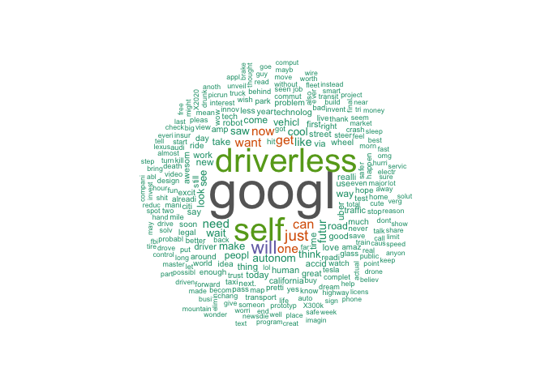

```r
# Load the wordcloud package
if(!require(wordcloud)){
  install.packages("wordcloud")
  library(wordcloud)
}
# Get word counts in decreasing order
word_freqs = sort(colSums(twittersparse), decreasing=TRUE)
# Create data frame with words and their frequencies
dm = data.frame(word=names(word_freqs), freq=unname(word_freqs))
# Plot wordcloud
wordcloud(dm$word, dm$freq, random.order=FALSE, colors=brewer.pal(8, "Dark2"))
```

Last step, we add the output variable (polarity of tweets) to the `twittersparse` dataframe. This is something we’ll need to make predictions.

```r
twittersparse$Neg <- twitter$Neg
str(twittersparse)
```

```
## 'data.frame':    2664 obs. of  266 variables:
##  $ invest    : num  1 0 0 0 0 0 0 0 0 0 ...
##  $ money     : num  1 0 0 0 0 0 0 0 0 0 ...
##  $ place     : num  1 0 0 0 0 0 0 0 0 0 ...
##  $ two       : num  1 0 0 0 0 0 0 0 0 0 ...
##  $ awesom    : num  0 1 0 0 0 0 1 0 0 0 ...
##  $ driverless: num  0 1 0 0 0 0 0 0 0 0 ...
##  $ googl     : num  0 1 0 0 0 0 1 1 1 0 ...
##  $ help      : num  0 1 0 0 0 0 0 0 0 0 ...
##  $ will      : num  0 1 0 0 0 0 0 0 0 0 ...
##  $ autonom   : num  0 0 1 0 0 1 1 1 1 1 ...
##  $ reduc     : num  0 0 1 0 0 0 0 0 0 0 ...
##  $ traffic   : num  0 0 1 0 0 0 0 0 0 0 ...
##  $ vehicl    : num  0 0 1 1 1 0 0 0 0 0 ...
##  $ check     : num  0 0 0 1 0 0 0 0 0 0 ...
```

[output cut: 86 more lines]

# 4 Train and test a classifier

Let’s prepare the data for our modelling exercise:

```r
# Load the caTools package and set the seed
if(!require(caTools)){
  install.packages("caTools")
  library(caTools)
}
set.seed(123)
# Create train and test sets (with balanced response)
spl <- sample.split(twittersparse$Neg,SplitRatio=0.7)
train <- subset(twittersparse,spl==TRUE)
test <- subset(twittersparse,spl==FALSE)
```

## 4.1 Logistc regression

Train:

```r
model1 <- glm(Neg~.,data=train,family=binomial)
summary(model1)
```

```
##
## Call:
## glm(formula = Neg ~ ., family = binomial, data = train)
##
## Deviance Residuals:
##     Min       1Q   Median       3Q      Max
## -3.4638  -0.6581  -0.2612   0.4670   2.9281
##
## Coefficients:
##               Estimate Std. Error z value Pr(>|z|)
## (Intercept) -4.644e-01  1.700e-01  -2.731 0.006309 **
## invest      -2.176e+00  1.109e+00  -1.962 0.049810 *
## money        9.262e-01  1.017e+00   0.911 0.362307
## place        1.288e+00  1.036e+00   1.243 0.213702
## two          6.215e-01  8.277e-01   0.751 0.452713
## awesom      -3.144e+00  1.091e+00  -2.881 0.003966 **
## driverless   5.060e-01  1.758e-01   2.879 0.003994 **
## googl       -2.579e-01  1.451e-01  -1.777 0.075558 .
## help        -2.363e-01  8.779e-01  -0.269 0.787825
## will        -1.869e-01  2.345e-01  -0.797 0.425419
## autonom      4.870e-01  3.945e-01   1.235 0.217002
## reduc       -2.511e+00  1.276e+00  -1.968 0.049050 *
## traffic     -1.530e+00  7.934e-01  -1.929 0.053762 .
## vehicl      -6.652e-01  4.003e-01  -1.662 0.096609 .
## check       -1.644e+01  9.774e+02  -0.017 0.986579
## good        -3.714e-01  5.108e-01  -0.727 0.467093
## realli       8.331e-02  4.710e-01   0.177 0.859612
## amaz        -1.748e+01  6.977e+02  -0.025 0.980012
## just         2.464e-01  2.930e-01   0.841 0.400416
## pretti      -6.244e-01  9.722e-01  -0.642 0.520697
## test        -4.282e-01  6.269e-01  -0.683 0.494602
## total       -1.811e+01  1.150e+03  -0.016 0.987439
## appl         5.275e-01  8.328e-01   0.633 0.526442
## control      6.182e-01  7.762e-01   0.796 0.425786
## smart       -1.927e-02  8.193e-01  -0.024 0.981240
## hour        -8.607e-01  8.457e-01  -1.018 0.308763
## now         -1.145e+00  3.908e-01  -2.931 0.003381 **
## wait        -2.408e+00  5.545e-01  -4.342 1.41e-05 ***
## cool        -2.609e+00  5.835e-01  -4.470 7.81e-06 ***
## technolog    8.444e-01  4.680e-01   1.804 0.071207 .
```

[output cut: 231 more lines]

```
## part         4.463e-01  9.268e-01   0.482 0.630131
## thought      9.088e-01  7.220e-01   1.259 0.208126
## goe          1.134e+00  1.096e+00   1.034 0.301190
## mayb         9.403e-01  9.198e-01   1.022 0.306631
## worri        1.894e+00  8.360e-01   2.266 0.023441 *
## ---
## Signif. codes:  0 '***' 0.001 '**' 0.01 '*' 0.05 '.' 0.1 ' ' 1
##
## (Dispersion parameter for binomial family taken to be 1)
##
##     Null deviance: 2247.4  on 1863  degrees of freedom
## Residual deviance: 1474.4  on 1598  degrees of freedom
## AIC: 2006.4
##
## Number of Fisher Scoring iterations: 16
```

Let’s take a quick look at the sign of some coefficients - `awesom` = -3.144 (lesser chance of negative sentiments) - `never` = 1.454 (higher chance of negative sentiments)

Let’s now try to make a prediction on the test data:

```r
predict1 <- predict(model1,newdata=test,type="response")
table(predict1>=0.5,test$Neg)
```

```
##
##         FALSE TRUE
##   FALSE   479  123
##   TRUE     88  110
```

The model accuracy is `0.73625`.

# 5 CART

Train:

```r
library(rpart)
library(rpart.plot)
model2 <- rpart(Neg~.,data=train)
summary(model2)
```

```
## Call:
## rpart(formula = Neg ~ ., data = train)
##   n= 1864
##
##           CP nsplit rel error    xerror       xstd
## 1 0.02214022      0 1.0000000 1.0000000 0.03617372
## 2 0.01845018      1 0.9778598 0.9944649 0.03611437
## 3 0.01660517      2 0.9594096 0.9870849 0.03603439
## 4 0.01000000      3 0.9428044 0.9870849 0.03603439
##
## Variable importance
##   job point trust
##    40    30    30
##
## Node number 1: 1864 observations,    complexity param=0.02214022
##   predicted class=FALSE  expected loss=0.2907725  P(node) =1
##     class counts:  1322   542
##    probabilities: 0.709 0.291
##   left son=2 (1850 obs) right son=3 (14 obs)
##   Primary splits:
##       job   < 0.5 to the left,  improve=11.476240, (0 missing)
##       trust < 0.5 to the left,  improve= 8.527087, (0 missing)
##       point < 0.5 to the left,  improve= 8.460918, (0 missing)
##       wait  < 0.5 to the right, improve= 8.365213, (0 missing)
##       cool  < 0.5 to the right, improve= 8.365213, (0 missing)
##
## Node number 2: 1850 observations,    complexity param=0.01845018
##   predicted class=FALSE  expected loss=0.2859459  P(node) =0.9924893
##     class counts:  1321   529
##    probabilities: 0.714 0.286
##   left son=4 (1830 obs) right son=5 (20 obs)
##   Primary splits:
##       trust < 0.5 to the left,  improve=8.707987, (0 missing)
##       point < 0.5 to the left,  improve=8.593911, (0 missing)
##       wait  < 0.5 to the right, improve=8.015407, (0 missing)
##       cool  < 0.5 to the right, improve=8.015407, (0 missing)
##       worri < 0.5 to the left,  improve=7.046842, (0 missing)
##
## Node number 3: 14 observations
##   predicted class=TRUE   expected loss=0.07142857  P(node) =0.00751073
```

[output cut: 14 more lines]

```
##
## Node number 5: 20 observations
##   predicted class=TRUE   expected loss=0.25  P(node) =0.01072961
##     class counts:     5    15
##    probabilities: 0.250 0.750
##
## Node number 8: 1819 observations
##   predicted class=FALSE  expected loss=0.2770753  P(node) =0.9758584
##     class counts:  1315   504
##    probabilities: 0.723 0.277
##
## Node number 9: 11 observations
##   predicted class=TRUE   expected loss=0.09090909  P(node) =0.005901288
##     class counts:     1    10
##    probabilities: 0.091 0.909
```

Tree visualization:

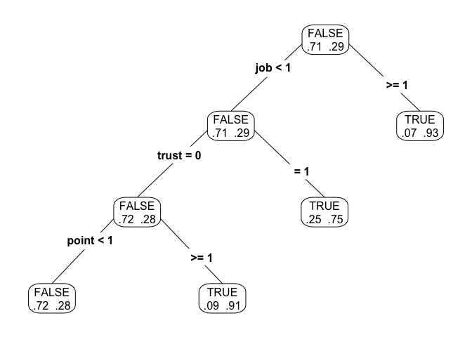

```r
prp(model2,type=4,extra=4) # Here, TRUE indicates Neg = 1, FALSE indicates Neg = 0.
```

Prediction:

```r
predict2 <- predict(model2,newdata=test,type="class")
table(predict2,test$Neg)
```

```
##
## predict2 FALSE TRUE
##    FALSE   560  217
##    TRUE      7   16
```

The model accuracy is `(560+16)/800`.

Let’s now try to build a deeper tree:

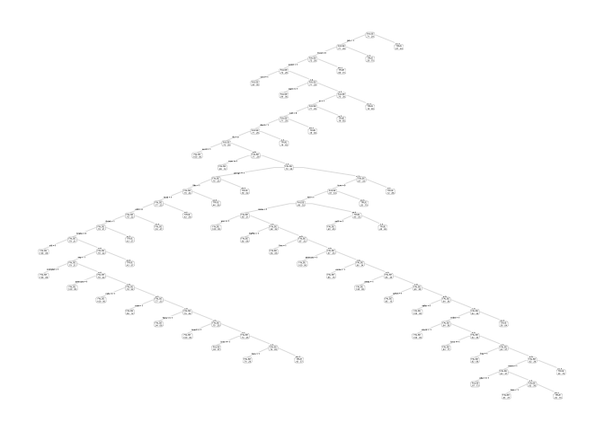

```r
model2a <- rpart(Neg~.,data=train,cp=10^-6)
prp(model2a,type=4,extra=4)
```

```r
printcp(model2a)
```

```
##
## Classification tree:
## rpart(formula = Neg ~ ., data = train, cp = 10^-6)
##
## Variables actually used in tree construction:
##  [1] amaz    awesom  brake   buy     call    citi    come    complet cool
## [10] cute    dont    electr  excit   fbi     futur   googl   great   job
## [19] kill    less    like    live    love    make    need    now     point
## [28] road    robot   safer   saw     say     seem    self    still   think
## [37] traffic tri     trust   turn    uber    wait    yes
##
## Root node error: 542/1864 = 0.29077
##
## n= 1864
##
##           CP nsplit rel error  xerror     xstd
## 1 0.02214022      0   1.00000 1.00000 0.036174
## 2 0.01845018      1   0.97786 0.99262 0.036094
## 3 0.01660517      2   0.95941 0.98708 0.036034
## 4 0.00492005      3   0.94280 0.98339 0.035994
## 5 0.00369004     16   0.85055 0.96863 0.035830
## 6 0.00092251     19   0.83948 0.95203 0.035641
## 7 0.00082001     23   0.83579 0.96863 0.035830
## 8 0.00023063     38   0.81365 0.98155 0.035974
## 9 0.00000100     46   0.81181 0.98339 0.035994
```

```r
# plotcp(model2a)
```

And now we prune it:

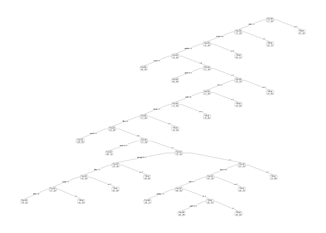

```r
model2b <- prune(model2a,cp=0.00092251) # To prune, we use the smallest value of xerror
prp(model2b,type=4,extra=4)
```

Prediction:

```r
predict2b <- predict(model2b,newdata=test,type="class")
table(predict2b,test$Neg)
```

```
##
## predict2b FALSE TRUE
##     FALSE   523  184
##     TRUE     44   49
```

The model accuracy is `(523+49)/800`.

# 6 Random Forests

Train:

```r
library(randomForest)
# We use the default parameters to fit the model (500 trees)
model3 <- randomForest(Neg~.,data=train)
# summary(model3)
model3
```

```
##
## Call:
##  randomForest(formula = Neg ~ ., data = train)
##                Type of random forest: classification
##                      Number of trees: 500
## No. of variables tried at each split: 16
##
##         OOB estimate of  error rate: 27.09%
## Confusion matrix:
##       FALSE TRUE class.error
## FALSE  1164  158   0.1195159
## TRUE    347  195   0.6402214
```

Prediction

```r
predict3 <- predict(model3,newdata=test,type="class")
table(predict3,test$Neg)
```

```
##
## predict3 FALSE TRUE
##    FALSE   496  140
##    TRUE     71   93
```